# 통계 방법론1 중간대체

## 실습 9. 모비율의 검정2

- customer.ds.csv
- 다음은 특정 제품을 구매한 지 1년이 지난 고객 중에서 n=1000명을 선택하여 전화 조사를 통하여 디자인(design)과 서비스(service) 만족도를 5점 척도로 조사한 것이다.
- 1. 4점 이상을 “만족”으로 가정한다
- 2. 고려한 제품은 디자인과 서비스 중에서 어떤 특성이 더 만족도가 높은가?
- 데이터 불러오기

```r
ds <- read.csv(paste0(data_path, "customer.ds.csv"))
str(ds)
```

```
## 'data.frame':    1000 obs. of  2 variables:
##  $ design : int  3 2 3 1 4 2 4 1 5 3 ...
##  $ service: int  5 5 4 1 4 1 5 4 1 5 ...
```

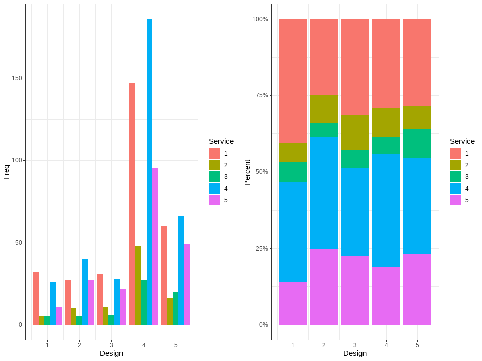

```r
# 막대그래프 생성 (dodge position)
ds1_plot <- ggplot(data = ds, aes(x = design, fill = factor(service), group = service)) +
  geom_bar(position = "dodge") +
  labs(x = "Design", y = "Freq", fill = "Service") +
  theme_bw()

# 막대그래프 생성 (fill position)
ds2_plot <- ggplot(data = ds, aes(x = design, fill = factor(service), group = service)) +
  geom_bar(position = "fill") +
  labs(x = "Design", y = "Percent", fill = "Service") +
  scale_y_continuous(labels = scales::percent) +
  theme_bw()

gridExtra::grid.arrange(ds1_plot, ds2_plot, ncol = 2)
```

- 만족 고객 구분 및 비교

```r
ds$d.satisfied <- ifelse(ds$design >= 4, "Yes", "No")
ds$s.satisfied <- ifelse(ds$service >= 4, "Yes", "No")
comparison <- table(ds$d.satisfied, ds$s.satisfied)

prop.test(comparison)
```

```
##
##  2-sample test for equality of proportions with continuity
##  correction
##
## data:  comparison
## X-squared = 0.2, df = 1, p-value = 0.7
## alternative hypothesis: two.sided
## 95 percent confidence interval:
##  -0.0546  0.0869
## sample estimates:
## prop 1 prop 2
##  0.462  0.445
```

- $\alpha$값은 휴리스틱에 의해 0.05로 설정한다.
- p-value = 0.7 > $\alpha$이므로 $H_{0}$기각 하지 못한다.
  - 따라서 두 특성의 만족도는 서로 다르다고 할 수 없다.

## 실습 10. 쌍체 데이터의 비율 비교

- 광고의 유용성을 확인하기 위하여 잠재 구매 고객을 두 개의 Group으로 나누고 광고를 보기 전에 제품을 구매할 것인가의 여부(buy, not buy) 그리고 동일한 고객이 광고를 접하고 난 후의 제품 구매 여부를 조사하였다. 이는 서로 다른 고객간의 의견 변동을 최소화 하기 위하여 설계되었다.
- 광고의 유용성 여부를 확인하시오.

| Before After | buy | not buy | Total |
| --- | --- | --- | --- |
| buy | 734 | 66 | 800 |
| not buy | 96 | 704 | 800 |
| **Total** | 830 | 770 | 1600 |

- 데이터 입력

```r
consumer <- matrix(c(734, 96, 66, 704), nrow = 2, ncol = 2)
dimnames(consumer) <- list(before.adv = c("buy", "not buy"),
                           after.adv = c("buy", "not buy"))
consumer
```

```
##           after.adv
## before.adv buy not buy
##    buy     734      66
##    not buy  96     704
```

- 검정 진행하기

```r
mcnemar.test(consumer)
```

```
##
##  McNemar's Chi-squared test with continuity correction
##
## data:  consumer
## McNemar's chi-squared = 5, df = 1, p-value = 0.02
```

- $\alpha$값은 휴리스틱에 의해 0.05로 설정한다.
- p-value = 0.02 < $\alpha$이므로 $H_{0}$기각한다.
  - 따라서 광고 전/후의 고객 구매 응답률은 서로 동일하지 않다.

## 실습 11. 지역/모델 별 고객 Claim 집계

- claim.area.2019.csv
- 다음은 일정 기간 동안 조사된 제품(model) 별 Customer/Partner 불만 사항의 빈도를 지역 별로 집계한 것이다.
- 데이터 불러오기

```r
claim19 <- read.csv(paste0(data_path, "claim.area.2019.csv"))
str(claim19)
```

```
## 'data.frame':    20 obs. of  3 variables:
##  $ model    : chr  "a_model1" "a_model2" "b_model1" "b_model2" ...
##  $ area     : chr  "1Domestic" "1Domestic" "1Domestic" "1Domestic" ...
##  $ frequency: int  107 51 32 27 71 30 21 9 29 21 ...
```

- 데이터 구조 확인

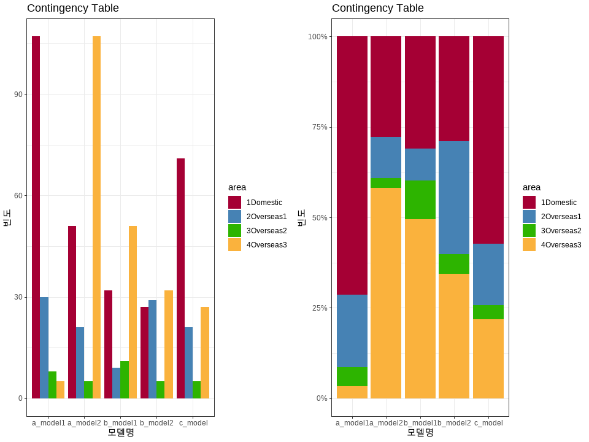

```r
my_color <- c(lre, sbl, ngr, lgo)
#
g1 <- claim19 %>%
        ggplot(aes(x = model, y = frequency, fill = area)) +
          geom_bar(stat = "identity", position = "dodge") +
          labs(title = "Contingency Table",
               x = "모델명", y = "빈도") +
          scale_fill_manual(values = my_color) +
          theme_bw()
#
g2 <-   claim19 %>%
          ggplot(aes(x = model, y = frequency, fill = area)) +
            geom_bar(stat = "identity", position = "fill") +
            labs(title = "Contingency Table",
                 x = "모델명", y = "빈도") +
            scale_fill_manual(values = my_color) +
            scale_y_continuous(labels = scales::percent) +
            theme_bw()
gridExtra::grid.arrange(g1, g2, ncol =2)
```

- Extra Visualiation1

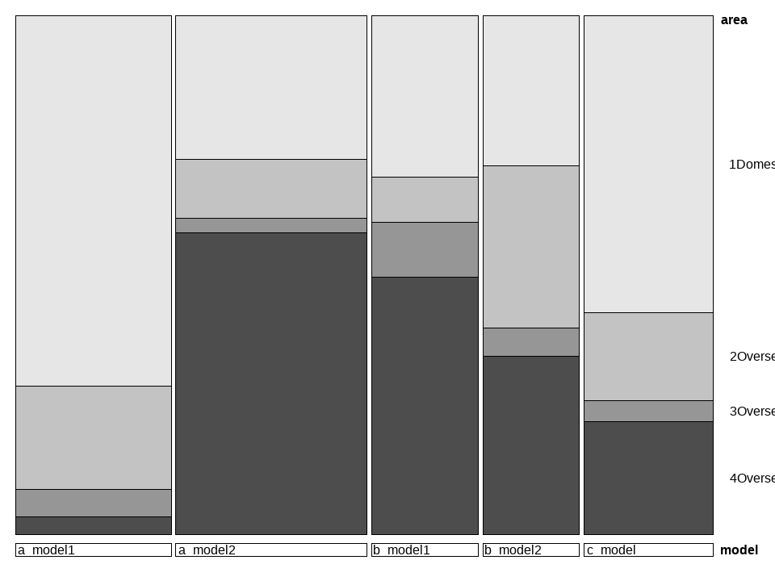

```r
claim19_t <- xtabs(frequency ~ model + area, claim19)
vcd::doubledecker(claim19_t)
```

- 카이제곱 독립성 검정
  - 모든 셀의 기대 도수(Expected)는 5보다 커야 한다. 그렇지 않으면 경고 메시지를 출력한다.

```r
result <- chisq.test(claim19_t)
```

```
## Warning in chisq.test(claim19_t): 카이제곱 approximation은 정확하지
## 않을수도 있습니다
```

```r
result
```

```
##
##  Pearson's Chi-squared test
##
## data:  claim19_t
## X-squared = 164, df = 12, p-value <0.0000000000000002
```

```r
result$p.value
```

```
## [1] 0.0000000000000000000000000000789
```

```r
result$expected
```

```
##           area
## model      1Domestic 2Overseas1 3Overseas2 4Overseas3
##   a_model1      66.1       25.2       7.80       50.9
##   a_model2      81.0       30.9       9.57       62.5
##   b_model1      45.4       17.3       5.35       35.0
##   b_model2      41.0       15.6       4.83       31.6
##   c_model       54.6       20.9       6.45       42.1
```

- Extra visualization2

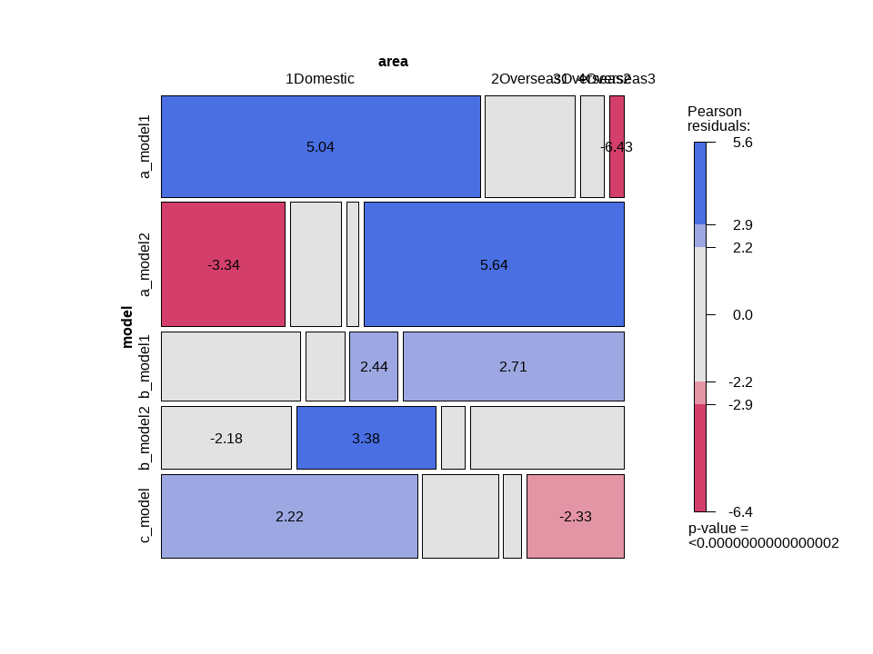

```r
claim19_t <- xtabs(frequency ~ model + area, claim19)
vcd::mosaic(claim19_t,
            gp = shading_max,
            labeling = labeling_residuals,
            digits = 2
            )
```

- 데이터 부분 선택: 해외향

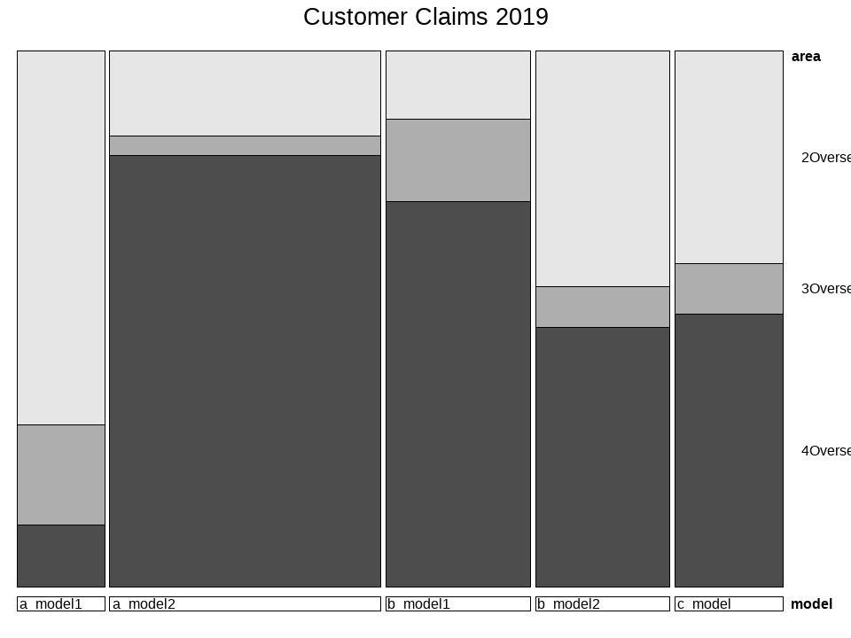

```r
claim19_2 <- claim19 %>%
  dplyr::filter(area != "1Domestic")
claim19_t2 <- xtabs(frequency ~ model + area, claim19_2)
vcd::doubledecker(claim19_t2, spacing = spacing_highlighting,
                  main = "Customer Claims 2019")
```

```r
result_2 <- chisq.test(claim19_t2)
result_2
```

```
##
##  Pearson's Chi-squared test
##
## data:  claim19_t2
## X-squared = 86, df = 8, p-value = 0.000000000000004
```

```r
result_2$p.value
```

```
## [1] 0.00000000000000358
```

```r
result_2$expected
```

```
##           area
## model      2Overseas1 3Overseas2 4Overseas3
##   a_model1       12.9       3.99       26.1
##   a_model2       40.0      12.36       80.7
##   b_model1       21.3       6.60       43.1
##   b_model2       19.8       6.13       40.0
##   c_model        15.9       4.92       32.1
```

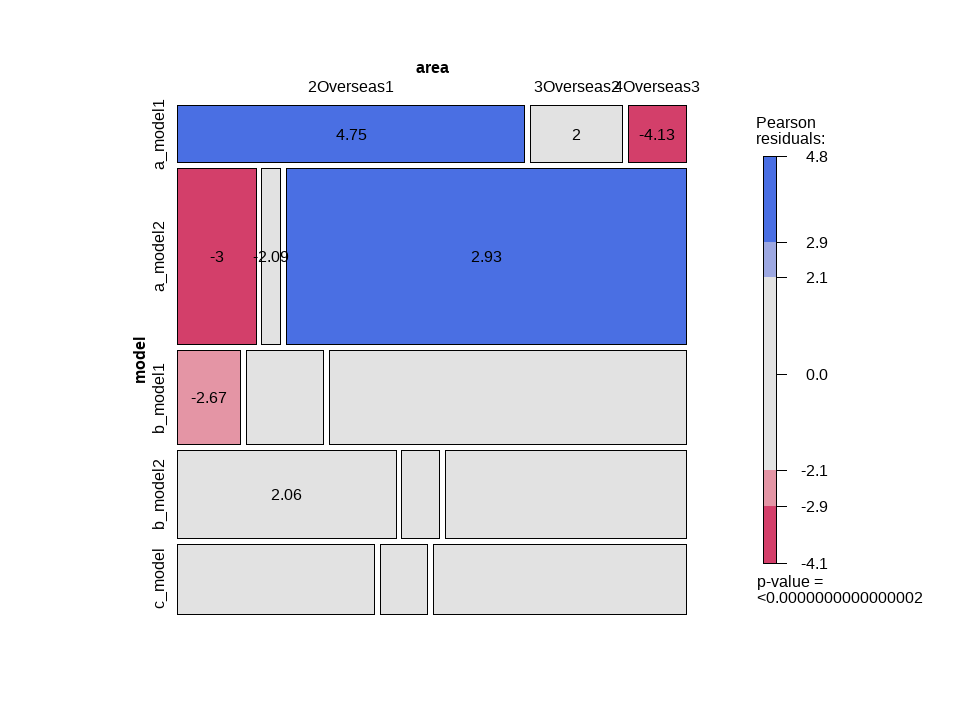

```r
mosaic(claim19_t2, gp = shading_max, labeling = labeling_residuals, digits = 2)
```

## 실습 12. 정규성 검정 Normality Test

- mid.measure.csv
- 다음은 생산 프로세스의 중간 단계에서 수집된 데이터로 목표값은 19.0(Micrometer, 0.001mm)이다.
- 데이터 불러오기 및 구조 확인

```r
check <- read.csv(paste0(data_path, "mid.measure.csv"))
str(check)
```

```
## 'data.frame':    363 obs. of  2 variables:
##  $ length: num  10.6 18.1 26.8 23.9 16.1 ...
##  $ set   : chr  "s3" "s3" "s4" "s4" ...
```

- 목표값 달성 유무와 산포 확인

```r
mean(check$length)
```

```
## [1] 19.1
```

```r
sd(check$length)
```

```
## [1] 3.97
```

```r
summary(check)
```

```
##      length         set
##  Min.   : 4.5   Length:363
##  1st Qu.:16.9   Class :character
##  Median :19.2   Mode  :character
##  Mean   :19.1
##  3rd Qu.:21.1
##  Max.   :33.2
```

- 분포 확인

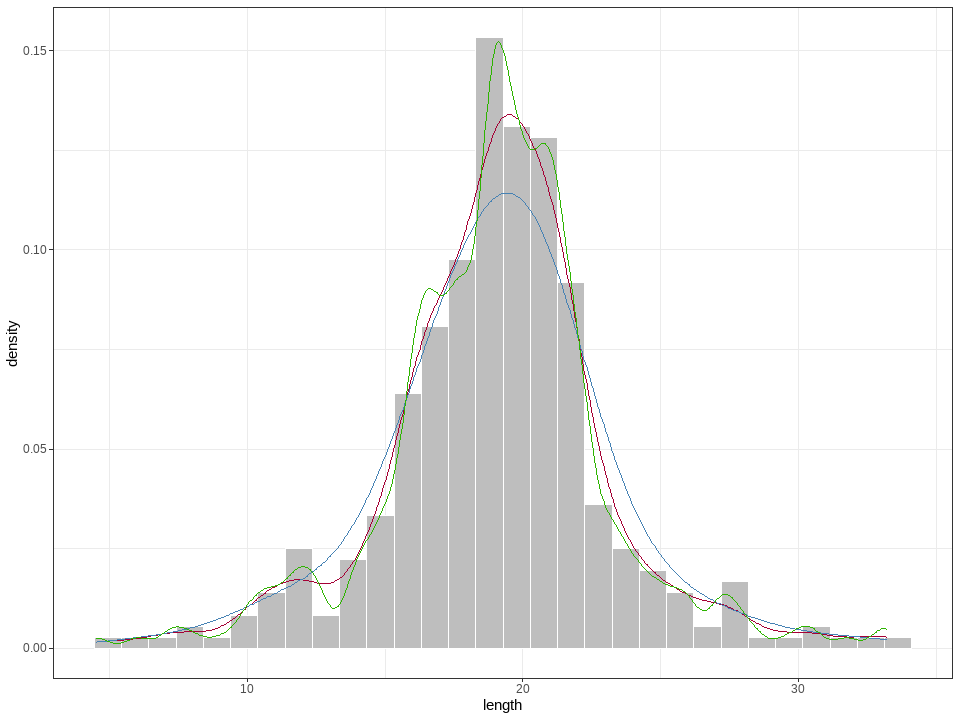

```r
check %>%
  ggplot(aes(length, y = ..density..)) +
  geom_histogram(color = "white", fill = "gray") +
  geom_density(color = lre) +
  geom_density(color = sbl, adjust = 2) +
  geom_density(color = ngr, adjust = 0.5) +
  theme_bw()
```

- Probability(Q-Q) Plot

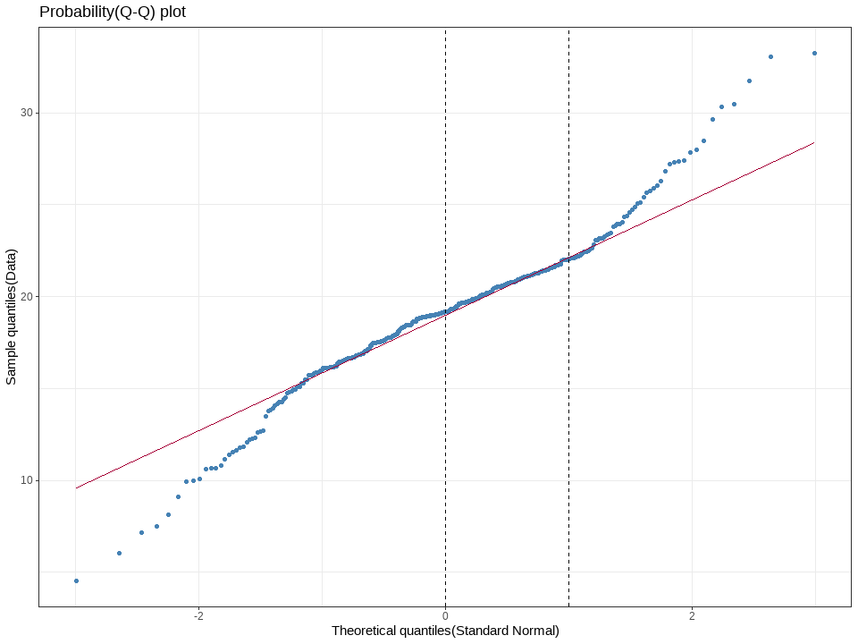

```r
check %>%
  ggplot(aes(sample = length)) +
  stat_qq(color = sbl) +
  stat_qq_line(color = lre) +
  geom_vline(xintercept = 0, linetype = "dashed") +
  geom_vline(xintercept = 1, linetype = "dashed") +
  labs(title = "Probability(Q-Q) plot",
       x = "Theoretical quantiles(Standard Normal)",
       y = "Sample quantiles(Data)"
       ) +
  theme_bw()
```

- 정규성 검정

```r
ad.test(check$length)
```

```
##
##  Anderson-Darling normality test
##
## data:  check$length
## A = 4, p-value = 0.0000000004
```

```r
pearson.test(check$length)
```

```
##
##  Pearson chi-square normality test
##
## data:  check$length
## P = 59, p-value = 0.000005
```

```r
ks.test(check$length, "pnorm")
```

```
##
##  Asymptotic one-sample Kolmogorov-Smirnov test
##
## data:  check$length
## D = 1, p-value <0.0000000000000002
## alternative hypothesis: two-sided
```

- 그룹 별 정규성 검정

```r
ad_tests <- lapply(split(check$length, check$set), ad.test)
p_values <- sapply(ad_tests, function(x) x$p.value)
p_values
```

```
##    s1    s2    s3    s4
## 0.869 0.286 0.572 0.482
```

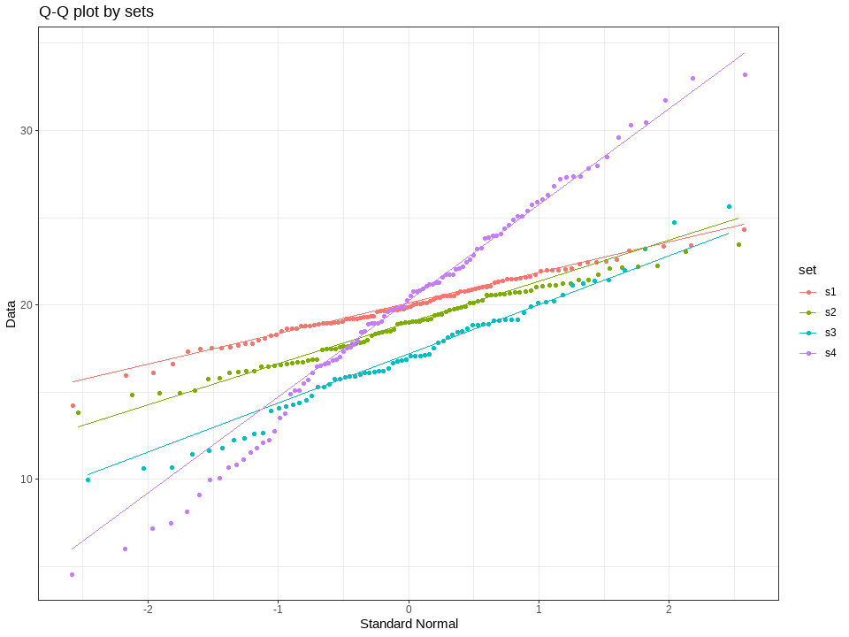

```r
check %>%
  ggplot(aes(sample = length, color = set)) +
  geom_qq() +
  stat_qq_line(aes(color = set)) +
  labs(title = "Q-Q plot by sets",
       x = "Standard Normal", y = "Data") +
  theme_bw()
```

- 그룹 별 모수(들) 추정
  - 단일 그룹 변수의 범주 별로 모수(그리고 표준오차)를 추정

```r
mid <- pars_group(check, length, set, "normal")

mid %>%
  bind_rows() %>%
  mutate(mean = purrr::map_dbl(fit, "mean"),
         sd = purrr::map_dbl(fit, "sd")
         ) %>%
  select(-fit)
```

```
## # A tibble: 4 × 3
##   set    mean    sd
##   <chr> <dbl> <dbl>
## 1 s1     20.0  1.77
## 2 s2     18.8  2.09
## 3 s3     17.0  3.23
## 4 s4     19.9  6.10
```

- what should we do now?

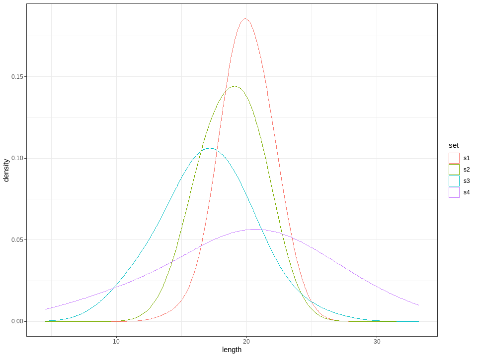

```r
check %>%
  ggplot(aes(x = length, color = set)) +
  geom_density(adjust = 2) +
  theme_bw()
```

## 실습 13. 정규성 변환(Box Cox Transformation)

- auto.defect.csv
- 다음은 반복 자동화 테스트에서 최초 결점이 발생할 때 까지의 시간(sec.s)을 조사한 것이다.
- 데이터 불러오기 및 구조 확인

```r
defect <- read.csv(paste0(data_path, "auto.defect.csv"))
str(defect)
```

```
## 'data.frame':    172 obs. of  2 variables:
##  $ id   : int  1 2 3 4 5 6 7 8 9 10 ...
##  $ times: num  124.9 65.2 113.1 27.7 123.3 ...
```

- 평균과 산포 확인

```r
mean(defect$times)
```

```
## [1] 112
```

```r
sd(defect$times)
```

```
## [1] 115
```

- 정규정 검정

```r
ad.test(defect$times)
```

```
##
##  Anderson-Darling normality test
##
## data:  defect$times
## A = 9, p-value <0.0000000000000002
```

```r
pearson.test(defect$times)
```

```
##
##  Pearson chi-square normality test
##
## data:  defect$times
## P = 122, p-value <0.0000000000000002
```

```r
ks.test(defect$times, "pnorm")
```

```
##
##  Asymptotic one-sample Kolmogorov-Smirnov test
##
## data:  defect$times
## D = 1, p-value <0.0000000000000002
## alternative hypothesis: two-sided
```

- p-value = 0.0000000000000002 < $\alpha = 0.05$ 이므로 $H_{0}$를 기각한다.
  - 데이터는 정규성을 만족하지 않는다.
  - BOX-COX 변환 시도
- Box-Cox Transformation

```r
x <- defect$times
bc <- boxcox(x ~ 1)
```

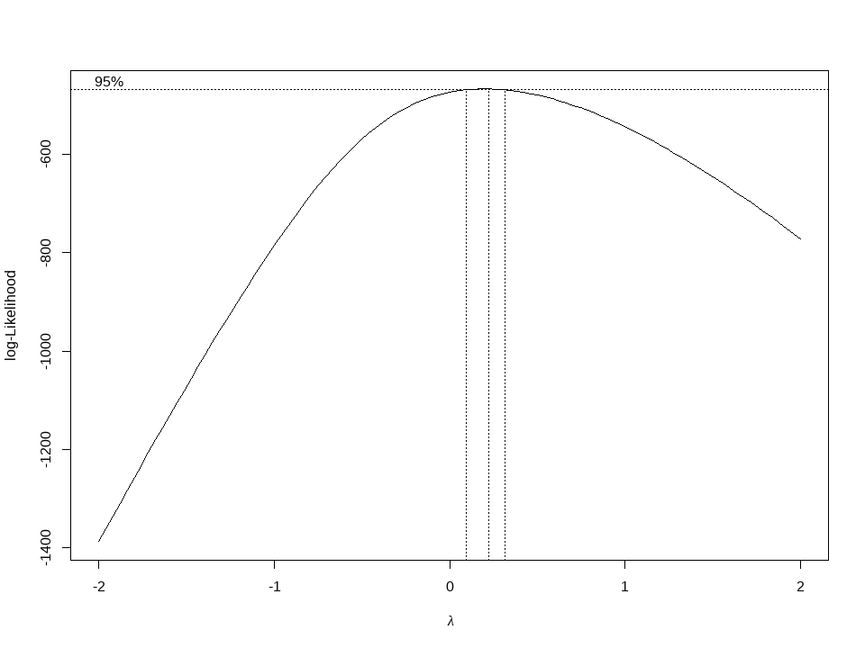

```r
lambda <- round(bc$x[which.max(bc$y)], 2)
x_trans <- (x^lambda -1) / lambda
ad.test(x_trans)
```

```
##
##  Anderson-Darling normality test
##
## data:  x_trans
## A = 0.2, p-value = 0.8
```

- 변환 후 분포 확인

```r
defect$trans0.2 <- x_trans
```

- 변환 전 후 mean 값 비교하기

```r
mean <- mean(defect$times)
mean_by_trans <- ((mean(x_trans)*lambda) + 1)^(1/lambda)
c(mean, mean_by_trans)
```

```
## [1] 111.7  73.8
```

- 변환 후 정규성 검정

```r
ad.test(defect$trans0.2)
```

```
##
##  Anderson-Darling normality test
##
## data:  defect$trans0.2
## A = 0.2, p-value = 0.8
```

```r
pearson.test(defect$trans0.2)
```

```
##
##  Pearson chi-square normality test
##
## data:  defect$trans0.2
## P = 9, p-value = 0.8
```

- p-value = 0.8 > $\alpha = 0.05$ 이므로 $H_{0}$를 기각하지 못한다.
  - 데이터는 정규성을 만족한다.

## 실습 14. 신제품 인증 시험 검증

- touch.ms.csv
- 신제품 인증 시험에서는 Touch 반응의 평균값의 230(ms)보다 작아야 한다.
  - 개선 활동의 검증에는 일반적으로 방향성 가설이 적절하다.
- 데이터 불러오기 및 구조 확인

```r
touch <- read.csv(paste0(data_path, "touch.ms.csv"))
str(touch)
```

```
## 'data.frame':    25 obs. of  2 variables:
##  $ id: int  1 2 3 4 5 6 7 8 9 10 ...
##  $ ms: num  226 233 228 231 235 ...
```

- 기초 통계량 확인

```r
c(mean = mean(touch$ms), stdDev = sd(touch$ms), max = max(touch$ms))
```

```
##   mean stdDev    max
## 228.99   3.26 234.70
```

- 정규성 검정

```r
ms <- touch$ms
test <- c(ad = ad.test(ms)$p.value, pearson = pearson.test(ms)$p.value)
round(test, 3)
```

```
##      ad pearson
##   0.214   0.198
```

- p-value > $\alpha = 0.05$ 이므로 $H_{0}$를 기각하지 못한다.
  - 따라서 데이터는 정규성을 따른다.

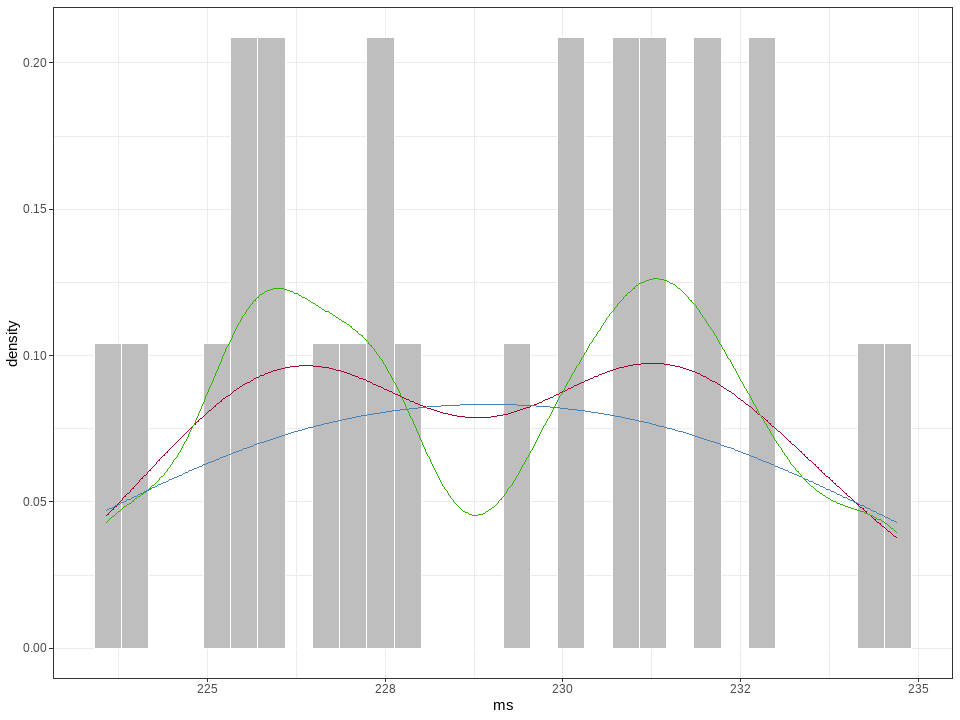

```r
touch %>%
  ggplot(aes(ms, y = ..density..)) +
  geom_histogram(color = "white", fill = "gray") +
  geom_density(color = lre) +
  geom_density(color = sbl, adjust = 2) +
  geom_density(color = ngr, adjust = 0.5) +
  theme_bw()
```

- 가설 검정 진행

```r
t.test(touch$ms, mu = 230, alternative = "less")
```

```
##
##  One Sample t-test
##
## data:  touch$ms
## t = -2, df = 24, p-value = 0.07
## alternative hypothesis: true mean is less than 230
## 95 percent confidence interval:
##  -Inf  230
## sample estimates:
## mean of x
##       229
```

- $\alpha$값은 휴리스틱에 의해 0.05로 설정한다.
- p-value = 0.07 > $\alpha$이므로 $H_{0}$기각할 수가 없다.
  - 결과를 살펴보면 표본 평균은 229로 나오지만, 모평균 $\mu$는 최대 230(ms)일 수 있다.
  - 따라서 기존 가설을 유지한다.

## 실습 15. 소음 개선 후 Pilot Sample 개선 검증

- noise.db.csv
- 제품의 소음(noise) 개선 전(old)/후(new)를 비교하여 개선 정도를 확인하고자 한다.
- 데이터 불러오기 및 구조 확인

```r
noise <- read.csv(paste0(data_path, "noise.db.csv"))
str(noise)
```

```
## 'data.frame':    76 obs. of  2 variables:
##  $ old: num  79 78 63.6 49.8 70.3 ...
##  $ new: num  34.3 23.8 33.8 45.5 51.3 ...
```

- 표본 평균과 표본 표준편차 확인

```r
c(old = mean(noise$old),
  new = mean(noise$new, na.rm = TRUE))
```

```
##  old  new
## 70.8 47.4
```

```r
c(old = sd(noise$old),
  new = sd(noise$new, na.rm = TRUE))
```

```
##  old  new
## 10.4 13.0
```

- 정규성 확인

```r
c(old = ad.test(noise$old)$p.value,
  new = ad.test(noise$new)$p.value)
```

```
##   old   new
## 0.933 0.429
```

- p-value > $\alpha = 0.05$ 이므로 $H_{0}$를 기각하지 못한다.
  - 따라서 데이터는 정규성을 따른다.
- 등분산성 확인

```r
var.test(noise$old, noise$new)
```

```
##
##  F test to compare two variances
##
## data:  noise$old and noise$new
## F = 0.6, num df = 75, denom df = 33, p-value = 0.1
## alternative hypothesis: true ratio of variances is not equal to 1
## 95 percent confidence interval:
##  0.34 1.10
## sample estimates:
## ratio of variances
##              0.633
```

- p-value > $\alpha = 0.05$ 이므로 $H_{0}$를 기각하지 못한다.
  - 따라서 등분산성을 만족한다.
  - t-test 진행
- t.test 진행

```r
t.test(noise$new, noise$old, alternative = "less", var.equal = TRUE)
```

```
##
##  Two Sample t-test
##
## data:  noise$new and noise$old
## t = -10, df = 108, p-value <0.0000000000000002
## alternative hypothesis: true difference in means is less than 0
## 95 percent confidence interval:
##   -Inf -19.6
## sample estimates:
## mean of x mean of y
##      47.4      70.8
```

- $\alpha$값은 휴리스틱에 의해 0.05로 설정한다.
- p-value = 0.0000000000000002 < $\alpha$=0.05이므로 $H_{0}$기각한다.
- 어느 정도로 성능이 개선되었느지 확인 진행

```r
alpha <- 0.05
for(Delta in seq(1, 30, by =1)){
  t.test_result <- t.test(noise$new + Delta,
                          noise$old,
                          alternative = "less",
                          var.equal =TRUE)
  if(t.test_result$p.value > alpha){
    cat("Delta = ", Delta, "에서 최초로 H_0를 기각하지 못한다.
        이때 p-value=", t.test_result$p.value, "\n")
    break
  }
}
```

```
## Delta =  20 에서 최초로 H_0를 기각하지 못한다.
##         이때 p-value= 0.0721
```

- 평균 소음은 최대 약 19.6(db) 정도 개선되었다.
  - 이렇게 분석을 진행하는 것이 방향성 가설이다.

## 실습 16. 쌍체 데이터의 차이의 모평균 비교

- exposure.con.csv
- 노출 시간은 표본 변이에 민감하며, 결과인 집적도(Concentration;C/m^2)에 영향을 준다.
- 연구자는 먼저 일정 수의 표본을 랜덤하게 선택한 후 각 표본에 노출 시간 1 min을 적용하여 집적도를 먼저 측정하고 동일한 표본에 2min.s 추가로 적용하여(총 3 min.s)집적도를 재측정하였다.
- 만일 노출 시간에 따른 집적도가 2.0(C/m^2)이상 차이가 난다면, 노출 시간을 3 min.s으로 변경하고자 한다.
- 데이터 불러오기

```r
con <- read.csv(paste0(data_path, "exposure.con.csv"))
str(con)
```

```
## 'data.frame':    55 obs. of  2 variables:
##  $ x1m: num  12.78 13.12 14.12 7.31 14.67 ...
##  $ x3m: num  15.23 16.54 15.87 8.73 23.6 ...
```

- 쌍체 검정의 유용성 확인

```r
cov(con$x1m, con$x3m)
```

```
## [1] 21.5
```

```r
cor(con$x1m, con$x3m)
```

```
## [1] 0.931
```

- 수집된 데이터는 강한 양(+)의 상관 관계를 갖는다.

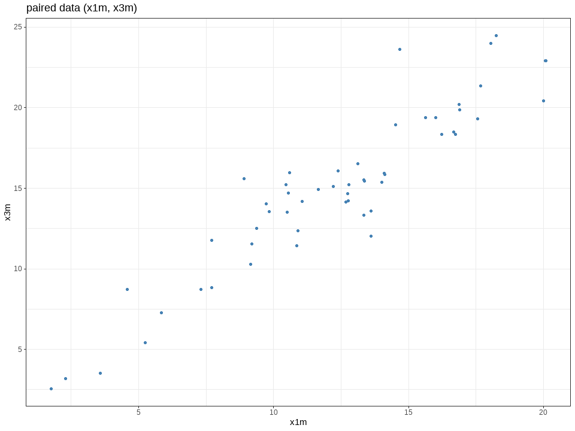

```r
con %>% ggplot(aes(x = x1m, y = x3m)) +
  geom_point(color = sbl) +
  labs(title = "paired data (x1m, x3m)") +
  theme_bw()
```

- 히스토그램과 정규확률그림

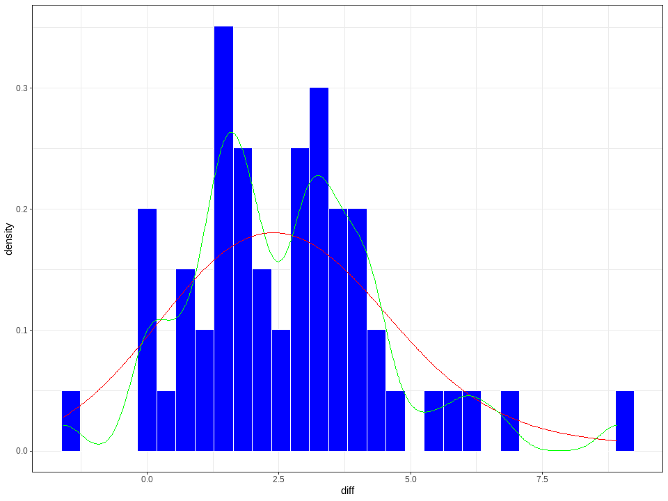

```r
con$diff <- con$x3m - con$x1m
hist_density(con, diff)
```

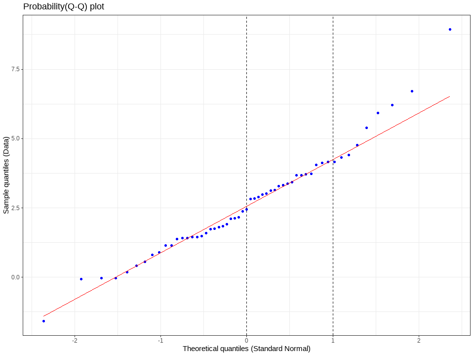

```r
qq_normal(con, diff)
```

- 히스토그램과 정규확률그림을 봤을 때 정규성을 만족하는 것으로 보인다.
- 쌍체 차이의 정규성 검정

```r
ad.test(con$diff)
```

```
##
##  Anderson-Darling normality test
##
## data:  con$diff
## A = 0.5, p-value = 0.3
```

- p-value = 0.3 > $\alpha = 0.05$이므로 $H_{0}$을 기각하지 못하여 정규분포를 따를 가능성이 있다고 판단한다.
- 쌍체 검정

```r
t.test(con$x3m, con$x1m, 2.0, alternative = "greater", paired = TRUE)
```

```
##
##  Paired t-test
##
## data:  con$x3m and con$x1m
## t = 3, df = 54, p-value = 0.007
## alternative hypothesis: true mean difference is greater than 2
## 95 percent confidence interval:
##  2.23  Inf
## sample estimates:
## mean difference
##            2.65
```

- p-value = 0.007 < 0.05 이므로 $H_{0}$를 기각한다.
- 2 sample t-test

```r
t.test(con$x3m, con$x1m, 2.0, alternative = "greater")
```

```
##
##  Welch Two Sample t-test
##
## data:  con$x3m and con$x1m
## t = 0.7, df = 106, p-value = 0.2
## alternative hypothesis: true difference in means is greater than 2
## 95 percent confidence interval:
##  1.13  Inf
## sample estimates:
## mean of x mean of y
##      14.8      12.1
```

- p-value = 0.2 > 0.05 이므로 $H_{0}$를 기각하지 못한다.
- paired t-test를 적용할 경우에는 노출 시간을 제외하고는 나머지 변동성은 통제하기 때문에 이렇게 2 sample t-test와 차이를 가지게 된다.
- 따라서, 노출 시간 3 min.s일 때와 1 min.s를 비교 했을 때 집적도가 2.0(C/m^2)이상 차이가 난다는 것은 통계적으로 유의하다.